# Bike Rentals in D.C.

Sebastian Kaltenbach

## Packages

Load the packages we need for this tutorial using the chunk below.

```r
library(tidyverse)
library(tidymodels)
library(dsbox)
```

## Recode season

Recode the season variable to be a factor with meaningful level names as outlined in the codebook, with spring as the baseline level.

```r
dcbikeshare <- dcbikeshare %>%
  mutate(
    season = case_when(
    season == 1 ~ "winter",
    season == 2 ~ "spring",
    season == 3 ~ "summer",
    season == 4 ~ "fall"
    ),
    season = fct_relevel(season, "spring", "summer", "fall", "winter")
  )
```

## Recode holiday and workingday

Recode the binary variables holiday and workingday to be factors with levels no (0) and yes (1), with no as the baseline level.

```r
dcbikeshare <- dcbikeshare %>%
  mutate(
    holiday = ifelse(holiday == 0, "no", "yes"),
    holiday = fct_relevel(holiday, "no", "yes"),
    workingday = ifelse(workingday == 0, "no", "yes"),
    workingday = fct_relevel(workingday, "no", "yes")
  )
```

## Recode year

Recode the yr variable to be a factor with levels 2011 and 2012, with 2011 as the baseline level.

```r
dcbikeshare <- dcbikeshare %>%
  mutate(
    yr = ifelse(yr == 0, "2011", "2012"),
    yr = fct_relevel(yr, "2011", "2012")
  )
```

## Recode weathersit

Recode the weathersit variable as 1 - clear, 2 - mist, 3 - light precipitation, and 4 - heavy precipitation, with clear as the baseline.

```r
dcbikeshare <- dcbikeshare %>%
  mutate(
    weathersit = case_when(
    weathersit == 1 ~ "clear",
    weathersit == 2 ~ "mist",
    weathersit == 3 ~ "light precipitation",
    weathersit == 4 ~ "heavy precipitation"
    ),
    weathersit = fct_relevel(weathersit, "clear", "mist", "light precipitation", "heavy precipitation")
  )
```

## Create raw values for temperature, humidity, and windspeed

Calculate raw temperature, feeling temperature, humidity, and windspeed as their values given in the dataset multiplied by the maximum raw values stated in the codebook for each variable. Instead of writing over the existing variables, create new ones called temperature_raw, feeling_temperature_raw, humidity_raw, windspeed_raw.

```r
dcbikeshare <- dcbikeshare %>%
  mutate(
    temperature_raw = temp * 41,
    feeling_temperature_raw = atemp * 50,
    humidity_raw = hum * 100,
    windspeed_raw = windspeed * 67
  )
```

## Check cnt variable

Check that the sum of casual and registered adds up to cnt for each record. Do this by creating a new column that takes on the value TRUE if they add up and FALSE if not, and then checking if all values in that column are TRUEs.

```r
dcbikeshare %>%
  mutate(cas_plus_reg = casual + registered) %>%
  summarise(all_zero = all(cas_plus_reg == cnt))
```

| all_zero |
| --- |
| TRUE |

## Recreating this visualization

Recreate the following visualization.

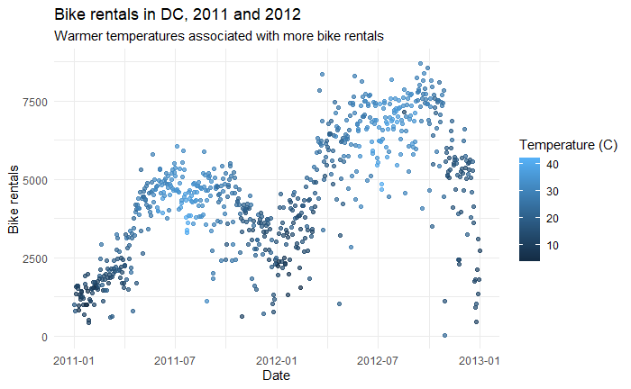

```r
dcbikeshare %>%
  ggplot(mapping = aes(x = dteday, y = cnt, color = feeling_temperature_raw)) +
    geom_point(alpha = 0.7) +
    labs(
      title = "Bike rentals in DC, 2011 and 2012",
      subtitle = "Warmer temperatures associated with more bike rentals",
      x = "Date",
      y = "Bike rentals",
      color = "Temperature (C)"
    ) +
  theme_minimal()
```

## Bike rentals vs temperature

Fit a linear model predicting total daily bike rentals from raw daily temperature and answer the questions below.

```r
cnt_tmp <- linear_reg() %>%
  set_engine("lm") %>%
  fit(cnt ~ temperature_raw, data = dcbikeshare)
cnt_tmp %>%
  tidy()
```

| term | estimate | std.error | statistic | p.value |
| --- | --- | --- | --- | --- |
| (Intercept) | 1214.6421 | 161.163531 | 7.536706 | 1.432673e-13 |
| temperature_raw | 161.9685 | 7.443611 | 21.759405 | 2.810622e-81 |

```r
glance(cnt_tmp)$r.squared
```

```
[1] 0.3937487
```

## Bike rentals vs feeling temperature

Fit another linear model predicting total daily bike rentals from raw daily feeling temperature. Then, proceed to answering the questions below.

```r
cnt_atmp <- linear_reg() %>%
  set_engine("lm") %>%
  fit(cnt ~ feeling_temperature_raw, data = dcbikeshare)
cnt_atmp %>%
  tidy()
```

| term | estimate | std.error | statistic | p.value |
| --- | --- | --- | --- | --- |
| (Intercept) | 945.8240 | 171.291469 | 5.521723 | 4.671196e-08 |
| feeling_temperature_raw | 150.0367 | 6.830765 | 21.964843 | 1.854504e-82 |

```r
glance(cnt_atmp)$r.squared
```

```
[1] 0.3982439
```

## Full model

Fit a model predicting total daily bike rentals from season, year, whether the day is holiday or not, whether the day is a workingday or not, the weather category, temperature, feeling temperature, humidity, and windspeed, as well as the interaction between feeling temperature and holiday.

```r
cnt_full <- linear_reg() %>%
  set_engine("lm") %>%
  fit(cnt ~ season + yr + holiday + workingday + weathersit +
        temperature_raw + feeling_temperature_raw + humidity_raw +
        windspeed_raw + feeling_temperature_raw * holiday, data = dcbikeshare)
tidy(cnt_full)
```

| term | estimate | std.error | statistic | p.value |
| --- | --- | --- | --- | --- |
| (Intercept) | 2715.14054 | 268.533836 | 10.1109811 | 1.475889e-22 |
| seasonsummer | -276.94853 | 100.344540 | -2.7599761 | 5.928162e-03 |
| seasonfall | 409.79210 | 96.164571 | 4.2613626 | 2.303159e-05 |
| seasonwinter | -1130.56069 | 113.544157 | -9.9570134 | 5.795629e-22 |
| yr2012 | 2014.06598 | 61.704875 | 32.6403057 | 6.375959e-144 |
| holidayyes | -1384.37860 | 495.409135 | -2.7944148 | 5.338259e-03 |
| workingdayyes | 119.67853 | 67.867412 | 1.7634167 | 7.825612e-02 |
| weathersitmist | -420.24376 | 81.285535 | -5.1699698 | 3.039898e-07 |
| weathersitlight precipitation | -1907.14902 | 207.547189 | -9.1889899 | 4.207726e-19 |
| temperature_raw | 102.99712 | 34.014628 | 3.0280243 | 2.549875e-03 |

[output cut: 4 more lines]

```r
glance(cnt_full)$adj.r.squared
```

```
[1] 0.8201774
```

## Backward selection

Perform the first step of backward selection by fitting a series of models, each with one explanatory variable removed from the full model you fit in the previous exercise. Record the adjusted R2s of each of these models.

In the chunk below, fit the full model without the season variable and print out the R2 score.

```r
rm_season <- linear_reg() %>%
  set_engine("lm") %>%
  fit(cnt ~ yr + holiday + workingday + weathersit +
        temperature_raw + feeling_temperature_raw + humidity_raw +
        windspeed_raw + feeling_temperature_raw * holiday, data = dcbikeshare)
glance(rm_season)$adj.r.squared
```

```
[1] 0.7491125
```

In the chunk below, fit the full model without the year variable and print out the adjusted R2 score.

```r
rm_year <- linear_reg() %>%
  set_engine("lm") %>%
  fit(cnt ~ season + holiday + workingday + weathersit +
        temperature_raw + feeling_temperature_raw + humidity_raw +
        windspeed_raw + feeling_temperature_raw * holiday, data = dcbikeshare)
glance(rm_year)$adj.r.squared
```

```
[1] 0.5536019
```

In the chunk below, fit the full model without the holiday variable and print out the adjusted R2 score. Remember to also remove the interaction effect between holiday and feeling_temperature_raw.

```r
rm_holiday <- linear_reg() %>%
  set_engine("lm") %>%
  fit(cnt ~ season + yr + workingday + weathersit +
        temperature_raw + feeling_temperature_raw + humidity_raw +
        windspeed_raw + feeling_temperature_raw, data = dcbikeshare)
glance(rm_holiday)$adj.r.squared
```

```
[1] 0.8172787
```

Fit the full model without the workingday variable using the code chunk below! Remember to record the adjusted R2 score.

```r
rm_workingday<- linear_reg() %>%
  set_engine("lm") %>%
  fit(cnt ~ season + yr + holiday + weathersit +
        temperature_raw + feeling_temperature_raw + humidity_raw +
        windspeed_raw + feeling_temperature_raw * holiday, data = dcbikeshare)
glance(rm_workingday)$adj.r.squared
```

```
[1] 0.8196491
```

Fit the full model without the weathersit variable in the chunk below and record the adjusted R2 score.

```r
rm_weathersit<- linear_reg() %>%
  set_engine("lm") %>%
  fit(cnt ~ season + yr + holiday + workingday +
        temperature_raw + feeling_temperature_raw + humidity_raw +
        windspeed_raw + feeling_temperature_raw * holiday, data = dcbikeshare)
glance(rm_weathersit)$adj.r.squared
```

```
[1] 0.7984698
```

Remove the temperature_raw variable in the chunk below and record the adjusted R2 score.

```r
rm_temp_raw<- linear_reg() %>%
  set_engine("lm") %>%
  fit(cnt ~ season + yr + holiday + workingday + weathersit +
        feeling_temperature_raw + humidity_raw +
        windspeed_raw + feeling_temperature_raw * holiday, data = dcbikeshare)
glance(rm_temp_raw)$adj.r.squared
```

```
[1] 0.8181315
```

In the chunk below, fit the full model without the feeling_temperature_raw variable and record the adjusted R2 score. Don’t forget to also remove the interaction effect between holiday and feeling_temperature_raw!

```r
rm_feeltemp_raw <- linear_reg() %>%
  set_engine("lm") %>%
  fit(cnt ~ season + yr + holiday + workingday + weathersit +
        temperature_raw + humidity_raw +
        windspeed_raw, data = dcbikeshare)
glance(rm_feeltemp_raw)$adj.r.squared
```

```
[1] 0.8198807
```

Fit the full model without the humidity_raw variable and record the adjusted R2 score.

```r
rm_humidity_raw <- linear_reg() %>%
  set_engine("lm") %>%
  fit(cnt ~ season + yr + holiday + workingday + weathersit +
        temperature_raw + feeling_temperature_raw +
        windspeed_raw + feeling_temperature_raw * holiday, data = dcbikeshare)
glance(rm_humidity_raw)$adj.r.squared
```

```
[1] 0.8151378
```

Fit the full model without the windspeed_raw variable and record the adjusted R2 score.

```r
rm_windspeed_raw <- linear_reg() %>%
  set_engine("lm") %>%
  fit(cnt ~ season + yr + holiday + workingday + weathersit +
        temperature_raw + feeling_temperature_raw + humidity_raw +
        feeling_temperature_raw * holiday, data = dcbikeshare)
glance(rm_windspeed_raw)$adj.r.squared
```

```
[1] 0.8106108
```

Last, remove the interaction effect between holiday and feeling_temperature_raw without removing the two variables individually. Then, record the adjusted R2.

```r
rm_interaction <- linear_reg() %>%
  set_engine("lm") %>%
  fit(cnt ~ season + yr + holiday + workingday + weathersit +
        temperature_raw + feeling_temperature_raw + humidity_raw +
        windspeed_raw, data = dcbikeshare)
glance(rm_interaction)$adj.r.squared
```

```
[1] 0.8197295
```